# Sudoku Observational Logging: Analysing Time, Difficulty and Progress

This data story explores my personal experience solving sudoku puzzles over time. The data being analysed includes the time taken to complete each puzzle, where the puzzle came from and both the source rated and my personal perceived difficulty of each puzzle. As an avid puzzler, I wanted to investigate how my solving experience changes with different puzzle difficulties and specifically examine whether source ratings of difficulty align with my own personal ratings.

## Do harder sudoku puzzles take longer to solve?

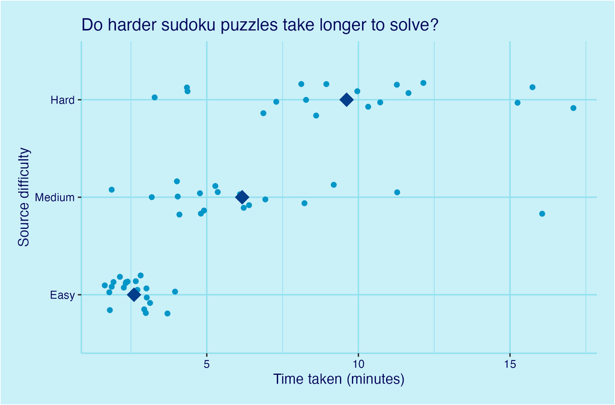

The above plot compares the time taken to solve sudoku puzzles across different source difficulty levels. Easy puzzles were generally completed more quickly with little variation in solving times. In comparison, medium and hard puzzles had more concentrated regions of points at higher times, suggesting a general trend that more difficult puzzles required longer to solve. However, medium and hard puzzles also displayed a wider spread of solving times. This implies that factors other than source difficulty ratings may affect how long a puzzle takes to solve. The overlap between times for some of the source difficulties also indicates that sources may not always rate puzzle difficulty accurately.

## Do sources accurately rate sudoku puzzle difficulty?

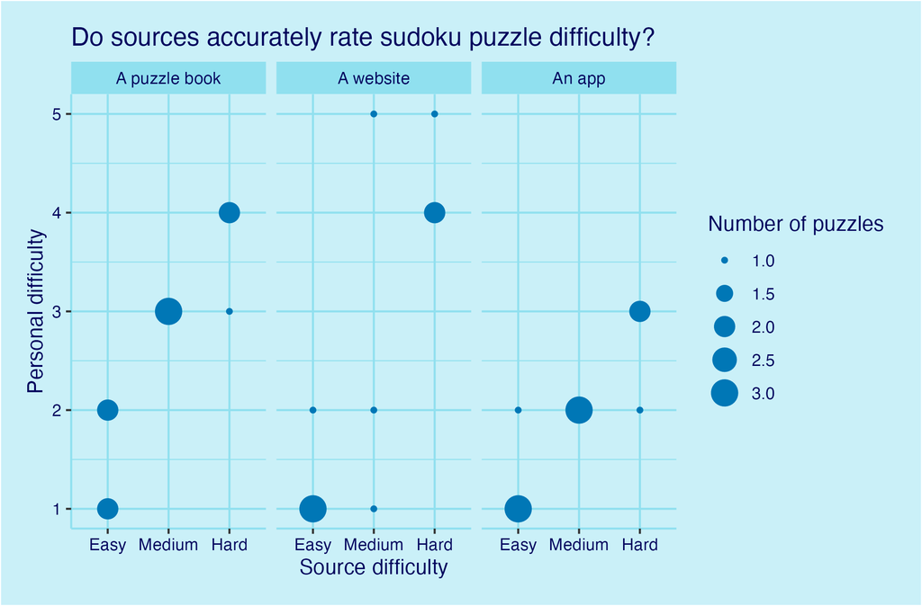

This plot compares the source difficulty with my personal difficulty rating for each of the puzzle sources. Sudoku sourced from puzzles books and apps show an accurate difficulty scale; medium puzzles seem harder than easy puzzles and hard puzzles seem harder than medium puzzles. However, for apps, we can see from the plot that I did not rate any puzzle higher than a 3 which suggests that the puzzles are not actually too difficult despite being rated hard by the source. Puzzles from puzzle books do seem to reflect a more accurate rating of difficulty overall with easy puzzles consistently being rated at 1 or 2, medium puzzles at 3 and hard puzzles at 3 or 4. The plot shows a notable disparity between personal difficulty ratings for medium puzzles from websites despite easy and hard puzzles being rated at low and high difficulties respectively. This suggests that websites are the least accurate out of the sources at rating the difficulty of sudoku puzzles.

## Did my sudoku solving time change throughout the observation period?

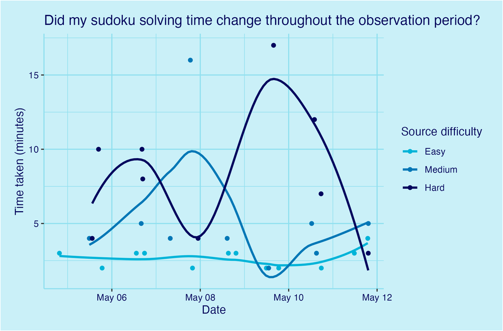

This plot shows how the time taken to complete a puzzle changed over time for each source difficulty level. We can see noticeable fluctuations in solving times, particularly for medium and hard puzzles. However, easy puzzles had consistently low solving times of under 5 minutes for the whole observation period. The trend lines for medium and hard puzzles do not indicate a clear trend over time, indicating that my solving ability remained the same, with no clear evidence of improvement.